# Silvergray Rockfish

*Sebastes brevispinis*

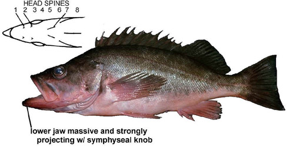

**Body color:** Dark gray-green to black on back becoming silver on sides and abruptly red-orange to white ventrally; lips blackened; lower portions of pectoral, anal, and pelvic fins washed w/ red-orange to pink.

**Peritoneum color:** light **Shape between eyes:** convex

**Counts:** D:XIII,13-17, Ar:7, P1:16-18, GR:33-36, LLp:44-53, LLs:58-70, V:26

**Occurence:** Bering Sea - Southern California

**Depth:** 375 meters **Size:** 71 cm **Species code:** 30100

**Similar species:**

- *Bocaccio* - body reddish; head spine count differs; gill rakers 27-32 (33-36 in Silvergray RF); anal rays typically 8 (7 in Silvergray)
- *Shortbelly rockfish* - anus midway between pelvic-fin base and anal-fin origin; body color reddish; head spine count differs; maximum length 32 cm
- *Chilipepper rockfish* - maxilla extends to midorbit; body reddish, lateral line clear red; anal rays 8-9 (7 in Silvergray RF)
- *Dusky rockfish* - head spines typically absent; body deeper; body brown to tan
- *Yellowtail rockfish* - body brassy w/ yellow fins; head spine count differs; body deeper

Back to Group

**Corrections:** If you see mistakes or want to suggest changes, please create an [issue](https://github.com/zoyafuso-NOAA/RACE_Survey_App/issues) on the source repository or

*reach out to Liz Dawson (Liz.Dawson AT noaa.gov).*